# Codice Vittadini

## Modello lineare multivariato e test d’ipotesi su restrizioni multiple

Iniziamo costruendo il modello multivariato

```r
mv1_countries<-lm(cbind(Life.expectancy, Unemployment)~ISPs.million+ Irrigated+ Under.14 +Literacy.Rate,countries)
summary(mv1_countries)
```

```
## Response Life.expectancy :
##
## Call:
## lm(formula = Life.expectancy ~ ISPs.million + Irrigated + Under.14 +
##     Literacy.Rate, data = countries)
##
## Residuals:
##      Min       1Q   Median       3Q      Max
## -21.3828  -3.3426   0.5599   4.3173  17.5504
##
## Coefficients:
##                 Estimate Std. Error t value Pr(>|t|)
## (Intercept)    9.261e+01  1.462e+01   6.333 3.63e-07 ***
## ISPs.million  -3.255e-02  1.861e-01  -0.175    0.862
## Irrigated      6.513e-06  1.493e-05   0.436    0.665
## Under.14      -9.566e-01  2.081e-01  -4.598 6.01e-05 ***
## Literacy.Rate  3.402e-02  1.125e-01   0.302    0.764
## ---
## Signif. codes:  0 '***' 0.001 '**' 0.01 '*' 0.05 '.' 0.1 ' ' 1
##
## Residual standard error: 7.867 on 33 degrees of freedom
## Multiple R-squared:  0.657,  Adjusted R-squared:  0.6155
## F-statistic:  15.8 on 4 and 33 DF,  p-value: 2.542e-07
##
##
## Response Unemployment :
##
## Call:
## lm(formula = Unemployment ~ ISPs.million + Irrigated + Under.14 +
##     Literacy.Rate, data = countries)
##
## Residuals:
##      Min       1Q   Median       3Q      Max
## -20.3115  -5.2740   0.5191   5.1450  24.1047
##
## Coefficients:
##                 Estimate Std. Error t value Pr(>|t|)
## (Intercept)   -2.725e+01  2.091e+01  -1.303   0.2015
## ISPs.million  -3.646e-02  2.660e-01  -0.137   0.8918
## Irrigated     -1.388e-05  2.134e-05  -0.650   0.5199
## Under.14       1.045e+00  2.974e-01   3.515   0.0013 **
## Literacy.Rate  1.497e-01  1.608e-01   0.931   0.3586
## ---
## Signif. codes:  0 '***' 0.001 '**' 0.01 '*' 0.05 '.' 0.1 ' ' 1
##
## Residual standard error: 11.25 on 33 degrees of freedom
## Multiple R-squared:  0.4257, Adjusted R-squared:  0.3561
## F-statistic: 6.116 on 4 and 33 DF,  p-value: 0.0008505
```

Vediamo che otteniamo esattamente gli stessi risultati di guardare i due modelli univariati in modo separato

Proseguiamo ora svolgendo test d’ ipotesi su restrizioni multiple

Iniziamo stimando un modello nullo, ovvero un modello in cui compaia la sola costante e tutti i coefficenti siano nulli, in quanto vogliamo testare HO: tutti i coefficenti=0 in entrambe le equazioni

```r
mvnull_countries<-lm(cbind(Life.expectancy, Unemployment)~1,countries)
anova(mv1_countries,mvnull_countries)
```

```
## Analysis of Variance Table
##
## Model 1: cbind(Life.expectancy, Unemployment) ~ ISPs.million + Irrigated +
##     Under.14 + Literacy.Rate
## Model 2: cbind(Life.expectancy, Unemployment) ~ 1
##   Res.Df Df Gen.var.  Pillai approx F num Df den Df    Pr(>F)
## 1     33      64.344
## 2     37  4  102.953 0.74566   4.9043      8     66 8.865e-05 ***
## ---
## Signif. codes:  0 '***' 0.001 '**' 0.01 '*' 0.05 '.' 0.1 ' ' 1
```

Vediamo che la statistica F risulta significativa e ciò ci porta a rifiutare l’ipotesi nulla, quindi vi è almeno un coefficente che è significativo per almeno una variabile dipendente

Andiamo a prendere ora i coefficienti che non sono significativi in entrambe le equazioni e andiamo a testarli:

- prima ipotesi il coefficente Irrigated=0 in entrambe le equazioni

```r
linearHypothesis(mv1_countries,hypothesis.matrix=c('Irrigated=0'))
```

```
##
## Sum of squares and products for the hypothesis:
##                 Life.expectancy Unemployment
## Life.expectancy        11.78022    -25.10959
## Unemployment          -25.10959     53.52120
##
## Sum of squares and products for error:
##                 Life.expectancy Unemployment
## Life.expectancy        2042.374    -2004.063
## Unemployment          -2004.063     4174.011
##
## Multivariate Tests:
##                  Df test stat  approx F num Df den Df Pr(>F)
## Pillai            1 0.0126660 0.2052553      2     32 0.8155
## Wilks             1 0.9873340 0.2052553      2     32 0.8155
## Hotelling-Lawley  1 0.0128285 0.2052553      2     32 0.8155
## Roy               1 0.0128285 0.2052553      2     32 0.8155
```

Vediamo che non si rifiuta l’ipotesi nulla, ovvero che irrigated non sia significativo per entrambe le equazioni, quindi proseguiamo a rimuovere irrigated da entrambi i modelli

Costruiamo il nuovo modello di regressione multivariata escludendo irrigated

```r
mv2_countries<-lm(cbind(Life.expectancy, Unemployment)~ISPs.million+ Under.14 +Literacy.Rate,countries)
summary(mv2_countries)
```

```
## Response Life.expectancy :
##
## Call:
## lm(formula = Life.expectancy ~ ISPs.million + Under.14 + Literacy.Rate,
##     data = countries)
##
## Residuals:
##      Min       1Q   Median       3Q      Max
## -21.4030  -3.0755   0.4149   4.3508  17.5113
##
## Coefficients:
##               Estimate Std. Error t value Pr(>|t|)
## (Intercept)   94.07054   14.06813   6.687 1.12e-07 ***
## ISPs.million  -0.02856    0.18360  -0.156    0.877
## Under.14      -0.97250    0.20237  -4.806 3.07e-05 ***
## Literacy.Rate  0.02451    0.10905   0.225    0.824
## ---
## Signif. codes:  0 '***' 0.001 '**' 0.01 '*' 0.05 '.' 0.1 ' ' 1
##
## Residual standard error: 7.773 on 34 degrees of freedom
## Multiple R-squared:  0.655,  Adjusted R-squared:  0.6246
## F-statistic: 21.52 on 3 and 34 DF,  p-value: 5.412e-08
##
##
## Response Unemployment :
##
## Call:
## lm(formula = Unemployment ~ ISPs.million + Under.14 + Literacy.Rate,
##     data = countries)
##
## Residuals:
##      Min       1Q   Median       3Q      Max
## -19.8336  -4.9370   0.3016   4.5583  24.1477
##
## Coefficients:
##                Estimate Std. Error t value Pr(>|t|)
## (Intercept)   -30.34887   20.18195  -1.504  0.14188
## ISPs.million   -0.04496    0.26340  -0.171  0.86548
## Under.14        1.07945    0.29032   3.718  0.00072 ***
## Literacy.Rate   0.17000    0.15644   1.087  0.28482
## ---
## Signif. codes:  0 '***' 0.001 '**' 0.01 '*' 0.05 '.' 0.1 ' ' 1
##
## Residual standard error: 11.15 on 34 degrees of freedom
## Multiple R-squared:  0.4184, Adjusted R-squared:  0.3671
## F-statistic: 8.153 on 3 and 34 DF,  p-value: 0.0003181
```

Vediamo che la variabile ISPs.million non è significativa, andiamo a testare che il coefficente ISPs.million=0 in entrambe le equazioni

```r
linearHypothesis(mv2_countries,hypothesis.matrix=c('ISPs.million=0'))
```

```
##
## Sum of squares and products for the hypothesis:
##                 Life.expectancy Unemployment
## Life.expectancy        1.461820     2.301222
## Unemployment           2.301222     3.622621
##
## Sum of squares and products for error:
##                 Life.expectancy Unemployment
## Life.expectancy        2054.154    -2029.173
## Unemployment          -2029.173     4227.532
##
## Multivariate Tests:
##                  Df test stat  approx F num Df den Df  Pr(>F)
## Pillai            1 0.0050029 0.0829631      2     33 0.92058
## Wilks             1 0.9949971 0.0829631      2     33 0.92058
## Hotelling-Lawley  1 0.0050281 0.0829631      2     33 0.92058
## Roy               1 0.0050281 0.0829631      2     33 0.92058
```

Vediamo che non si rifiuta l’ipotesi nulla, ovvero che ISP.million non sia significativo per entrambe le equazioni, quindi proseguiamo a rimuovere ISP.million da entrambi i modelli

Costruiamo il nuovo modello di regressione multivariata escludendo ISP.million

```r
mv3_countries<-lm(cbind(Life.expectancy, Unemployment)~ Under.14 +Literacy.Rate,countries)
summary(mv3_countries)
```

```
## Response Life.expectancy :
##
## Call:
## lm(formula = Life.expectancy ~ Under.14 + Literacy.Rate, data = countries)
##
## Residuals:
##      Min       1Q   Median       3Q      Max
## -21.3843  -2.8877   0.4936   4.4272  17.5317
##
## Coefficients:
##               Estimate Std. Error t value Pr(>|t|)
## (Intercept)   93.80617   13.76903   6.813 6.67e-08 ***
## Under.14      -0.96430    0.19264  -5.006 1.58e-05 ***
## Literacy.Rate  0.02349    0.10732   0.219    0.828
## ---
## Signif. codes:  0 '***' 0.001 '**' 0.01 '*' 0.05 '.' 0.1 ' ' 1
##
## Residual standard error: 7.664 on 35 degrees of freedom
## Multiple R-squared:  0.6548, Adjusted R-squared:  0.6351
## F-statistic:  33.2 on 2 and 35 DF,  p-value: 8.245e-09
##
##
## Response Unemployment :
##
## Call:
## lm(formula = Unemployment ~ Under.14 + Literacy.Rate, data = countries)
##
## Residuals:
##      Min       1Q   Median       3Q      Max
## -19.8864  -4.9807   0.4401   4.7070  24.1772
##
## Coefficients:
##               Estimate Std. Error t value Pr(>|t|)
## (Intercept)   -30.7650    19.7543  -1.557 0.128377
## Under.14        1.0924     0.2764   3.952 0.000358 ***
## Literacy.Rate   0.1684     0.1540   1.094 0.281580
## ---
## Signif. codes:  0 '***' 0.001 '**' 0.01 '*' 0.05 '.' 0.1 ' ' 1
##
## Residual standard error: 11 on 35 degrees of freedom
## Multiple R-squared:  0.4179, Adjusted R-squared:  0.3846
## F-statistic: 12.56 on 2 and 35 DF,  p-value: 7.721e-05
```

```r
linearHypothesis(mv3_countries,hypothesis.matrix=c('Literacy.Rate=0'))
```

```
##
## Sum of squares and products for the hypothesis:
##                 Life.expectancy Unemployment
## Life.expectancy        2.813344     20.16898
## Unemployment          20.168980    144.59227
##
## Sum of squares and products for error:
##                 Life.expectancy Unemployment
## Life.expectancy        2055.616    -2026.872
## Unemployment          -2026.872     4231.155
##
## Multivariate Tests:
##                  Df test stat approx F num Df den Df  Pr(>F)
## Pillai            1 0.0784870 1.447923      2     34 0.24919
## Wilks             1 0.9215130 1.447923      2     34 0.24919
## Hotelling-Lawley  1 0.0851719 1.447923      2     34 0.24919
## Roy               1 0.0851719 1.447923      2     34 0.24919
```

Vediamo che non si rifiuta l’ipotesi nulla, ovvero che Literacy.Rate non sia significativo per entrambe le equazioni, quindi proseguiamo a rimuovere Literacy.Rate da entrambi i modelli

Costruiamo il nuovo modello di regressione multivariata escludendo Literacy.Rate

```r
mv4_countries<-lm(cbind(Life.expectancy, Unemployment)~ Under.14,countries)
summary(mv4_countries)
```

```
## Response Life.expectancy :
##
## Call:
## lm(formula = Life.expectancy ~ Under.14, data = countries)
##
## Residuals:
##      Min       1Q   Median       3Q      Max
## -21.0250  -2.9740   0.4021   4.7701  17.8797
##
## Coefficients:
##             Estimate Std. Error t value Pr(>|t|)
## (Intercept)  96.7036     3.7354  25.888   <2e-16 ***
## Under.14     -0.9969     0.1208  -8.255    8e-10 ***
## ---
## Signif. codes:  0 '***' 0.001 '**' 0.01 '*' 0.05 '.' 0.1 ' ' 1
##
## Residual standard error: 7.562 on 36 degrees of freedom
## Multiple R-squared:  0.6543, Adjusted R-squared:  0.6447
## F-statistic: 68.15 on 1 and 36 DF,  p-value: 7.998e-10
##
##
## Response Unemployment :
##
## Call:
## lm(formula = Unemployment ~ Under.14, data = countries)
##
## Residuals:
##      Min       1Q   Median       3Q      Max
## -21.0690  -5.1599  -0.6156   4.7316  26.7526
##
## Coefficients:
##             Estimate Std. Error t value Pr(>|t|)
## (Intercept)  -9.9935     5.4463  -1.835   0.0748 .
## Under.14      0.8589     0.1761   4.878 2.18e-05 ***
## ---
## Signif. codes:  0 '***' 0.001 '**' 0.01 '*' 0.05 '.' 0.1 ' ' 1
##
## Residual standard error: 11.02 on 36 degrees of freedom
## Multiple R-squared:  0.398,  Adjusted R-squared:  0.3813
## F-statistic:  23.8 on 1 and 36 DF,  p-value: 2.177e-05
```

Andiamo adesso a vedere cos’è successo nei vari modelli per quanto riguarda la bontà di adattamento

```r
summary(mv1_countries)$`Response Life.expectancy`$adj.r.squared
```

```
## [1] 0.6154522
```

```r
summary(mv2_countries)$`Response Life.expectancy`$adj.r.squared
```

```
## [1] 0.6246097
```

```r
summary(mv3_countries)$`Response Life.expectancy`$adj.r.squared
```

```
## [1] 0.6350756
```

```r
summary(mv4_countries)$`Response Life.expectancy`$adj.r.squared
```

```
## [1] 0.6447268
```

```r
summary(mv1_countries)$`Response Unemployment`$adj.r.squared
```

```
## [1] 0.3561386
```

```r
summary(mv2_countries)$`Response Unemployment`$adj.r.squared
```

```
## [1] 0.3670626
```

```r
summary(mv3_countries)$`Response Unemployment`$adj.r.squared
```

```
## [1] 0.3846196
```

```r
summary(mv4_countries)$`Response Unemployment`$adj.r.squared
```

```
## [1] 0.3812681
```

### MODELLO SUR

Consegna: Regressioni lineari multiple di packpc sulle covariate cpi, pop, income e tax per gli stati Arkansas (state=”AR”) e California (state=”CA”)

N.B: la fase di preprocessing con subsetting è stata già effettuata ed esposta nella sezione di preprocessing

Andiamo adesso a stimare i modelli di regressione, questi due modelli hanno variabili diverse (es. income viene trattato diversamente per ognun dei due stati, l’unica variabile in comune è cpi)

```r
ar1<-lm(packpc_AR~cpi+pop_AR+income_AR+tax_AR,cigarettesarca)
summary(ar1)
```

```
##
## Call:
## lm(formula = packpc_AR ~ cpi + pop_AR + income_AR + tax_AR, data = cigarettesarca)
##
## Residuals:
##     Min      1Q  Median      3Q     Max
## -2.1297 -0.9481 -0.4056  0.5941  3.4628
##
## Coefficients:
##               Estimate Std. Error t value Pr(>|t|)
## (Intercept)  4.195e+02  8.439e+01   4.971  0.00252 **
## cpi         -2.577e+02  6.589e+01  -3.912  0.00788 **
## pop_AR      -6.305e-05  4.495e-05  -1.403  0.21032
## income_AR    6.858e-06  1.869e-06   3.670  0.01046 *
## tax_AR      -1.333e+00  5.979e-01  -2.229  0.06735 .
## ---
## Signif. codes:  0 '***' 0.001 '**' 0.01 '*' 0.05 '.' 0.1 ' ' 1
##
## Residual standard error: 2.311 on 6 degrees of freedom
## Multiple R-squared:  0.9563, Adjusted R-squared:  0.9272
## F-statistic: 32.82 on 4 and 6 DF,  p-value: 0.0003231
```

```r
ca1<-lm(packpc_CA~cpi+pop_CA+income_CA+tax_CA,cigarettesarca)
summary(ca1)
```

```
##
## Call:
## lm(formula = packpc_CA ~ cpi + pop_CA + income_CA + tax_CA, data = cigarettesarca)
##
## Residuals:
##      Min       1Q   Median       3Q      Max
## -0.99694 -0.33594  0.07137  0.30917  1.27674
##
## Coefficients:
##               Estimate Std. Error t value Pr(>|t|)
## (Intercept)  2.788e+02  3.336e+01   8.358 0.000159 ***
## cpi         -6.138e+01  1.290e+01  -4.756 0.003138 **
## pop_CA      -4.806e-06  1.593e-06  -3.016 0.023506 *
## income_CA    3.840e-08  3.305e-08   1.162 0.289449
## tax_CA      -1.120e-01  7.017e-02  -1.596 0.161627
## ---
## Signif. codes:  0 '***' 0.001 '**' 0.01 '*' 0.05 '.' 0.1 ' ' 1
##
## Residual standard error: 0.7991 on 6 degrees of freedom
## Multiple R-squared:  0.9985, Adjusted R-squared:  0.9974
## F-statistic: 976.3 on 4 and 6 DF,  p-value: 1.442e-08
```

Vediamo che F è significativo, buona capacità di adattamento ai dati, variabili significative cpi e pop_ca

Andiamo a vedere le correlazioni tra i due modelli

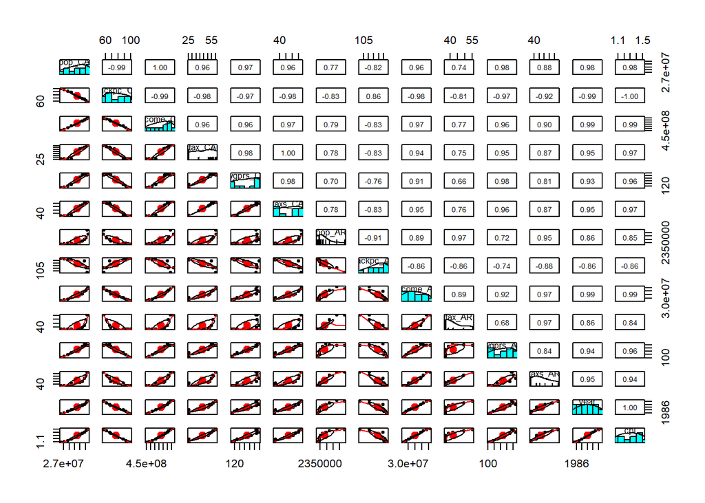

```r
pairs.panels(cigarettesarca)
```

Notiamo che ci sono delle correlazioni molto grandi, questo è dovuto al fatto che le variabili sono state costruite dalla stessa variabile

Ora dovremmo andare a vedere le ipotesi del modello lineare classico per ognuno dei due modelli (lo facciamo solo per uno in maniera del tutto didattica anche perchè non è lo scopo di questa parte)

```r
vif(ar1)
```

```
##       cpi    pop_AR income_AR    tax_AR
## 206.94592  17.84578 298.48359  38.50857
```

```r
#vediamo che ci sono dei problemi di multicollinearità molto importanti
white.test(ar1)
```

```
##   Test.Statistic         P
## 1       2.019625 0.3642873
```

```r
#abbiamo errori omoschedastici
ols_test_normality(ar1)
```

```
## -----------------------------------------------
##        Test             Statistic       pvalue
## -----------------------------------------------
## Shapiro-Wilk              0.9071         0.2253
## Kolmogorov-Smirnov        0.2383         0.4870
## Cramer-von Mises          1.4848          1e-04
## Anderson-Darling          0.4575         0.2121
## -----------------------------------------------
```

```r
#vediamo che abbiamo degli errori normali
```

Andiamo ora a vedere la correlazione tra i residui di ar1 e ca1

```r
cor(resid(ar1),resid(ca1))
```

```
## [1] 0.5666212
```

Vediamo che c’è una correlazione del 56% dei residui che non è poco, quindi possiamo utilizzare un modello apposito che accomoda questa condizione di correlazione dei residui, ovvero la integra all’interno del modello stesso. Ovvero il modello SUR

Andiamo quindi a costruire un modello SUR

Dobbiamo inanzitutto memorizzare le nostre regressioni all’interno di una lista

```r
elemento1<-packpc_AR~cpi+pop_AR+income_AR+tax_AR
elemento2<-packpc_CA~cpi+pop_CA+income_CA+tax_CA
sistema<-list(e1=elemento1,e2=elemento2)
```

Entriamo nel vivo del modello sure tramite la libreria systemfit

```r
sur_cigarettes<-systemfit(sistema,'SUR',data=cigarettesarca)
summary(sur_cigarettes)
```

```
##
## systemfit results
## method: SUR
##
##         N DF     SSR detRCov   OLS-R2 McElroy-R2
## system 22 12 38.9895 1.24531 0.987932   0.998651
##
##     N DF      SSR      MSE     RMSE      R2   Adj R2
## e1 11  6 34.79245 5.798741 2.408057 0.95255 0.920916
## e2 11  6  4.19707 0.699512 0.836368 0.99832 0.997199
##
## The covariance matrix of the residuals used for estimation
##         e1       e2
## e1 5.34166 1.046491
## e2 1.04649 0.638571
##
## The covariance matrix of the residuals
##         e1       e2
## e1 5.79874 1.676596
## e2 1.67660 0.699512
##
## The correlations of the residuals
##          e1       e2
## e1 1.000000 0.832461
## e2 0.832461 1.000000
##
##
## SUR estimates for 'e1' (equation 1)
## Model Formula: packpc_AR ~ cpi + pop_AR + income_AR + tax_AR
##
##                 Estimate   Std. Error  t value  Pr(>|t|)
## (Intercept)  3.63192e+02  7.08173e+01  5.12857 0.0021600 **
## cpi         -2.49217e+02  5.84900e+01 -4.26084 0.0053163 **
## pop_AR      -3.74634e-05  3.75376e-05 -0.99803 0.3567999
## income_AR    6.52862e-06  1.65535e-06  3.94394 0.0075902 **
## tax_AR      -1.43426e+00  5.24627e-01 -2.73386 0.0340115 *
## ---
## Signif. codes:  0 '***' 0.001 '**' 0.01 '*' 0.05 '.' 0.1 ' ' 1
##
## Residual standard error: 2.408057 on 6 degrees of freedom
## Number of observations: 11 Degrees of Freedom: 6
## SSR: 34.792445 MSE: 5.798741 Root MSE: 2.408057
## Multiple R-Squared: 0.95255 Adjusted R-Squared: 0.920916
##
##
## SUR estimates for 'e2' (equation 2)
## Model Formula: packpc_CA ~ cpi + pop_CA + income_CA + tax_CA
##
##                 Estimate   Std. Error  t value   Pr(>|t|)
## (Intercept)  2.88314e+02  2.80560e+01 10.27636 4.9571e-05 ***
## cpi         -6.77451e+01  1.20047e+01 -5.64320  0.0013272 **
## pop_CA      -5.20450e-06  1.36478e-06 -3.81344  0.0088280 **
## income_CA    5.63196e-08  2.82632e-08  1.99268  0.0933686 .
## tax_CA      -1.27173e-01  6.12950e-02 -2.07477  0.0833353 .
## ---
## Signif. codes:  0 '***' 0.001 '**' 0.01 '*' 0.05 '.' 0.1 ' ' 1
##
## Residual standard error: 0.836368 on 6 degrees of freedom
## Number of observations: 11 Degrees of Freedom: 6
## SSR: 4.197071 MSE: 0.699512 Root MSE: 0.836368
## Multiple R-Squared: 0.99832 Adjusted R-Squared: 0.997199
```

Vediamo che abbiamo degli R^2 molto simili alle stime precedenti e aumentano le variabili che sono significative, mentre i coefficienti non sono cambiati di molto rispetto a quelli precedenti